# TP53 reporter library scan - detailed analysis

Max Trauernicht

Netherlands Cancer Institute - van Steensel lab  
m.trauernicht@nki.nl

07/02/2023

### Introduction

~6,000 barcoded TP53 reporters were probed in MCF7 TP53WT/KO cells and stimulated with Nutlin-3a. I previously processed the raw sequencing data, quantified the pDNA data and normalized the cDNA data. In this script, a detailed dissection of the reporter activities will be carried out to understand how TP53 drives transcription and to identify the most sensitive TP53 reporters.

## Setup

### Load data

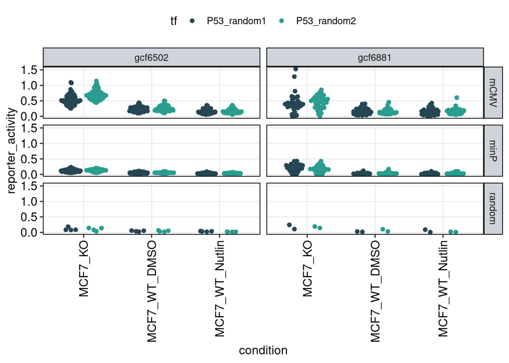

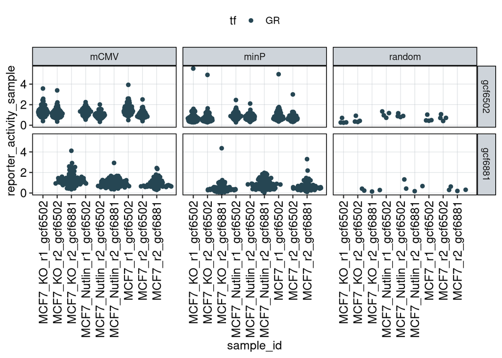

## Figure 1: Characterize P53 activities per condition

Aim: I want to characterize the reporter activity distributions in the tested conditions. Does Nutlin boost P53 reporter activity and is P53 inactive in the KO cells?

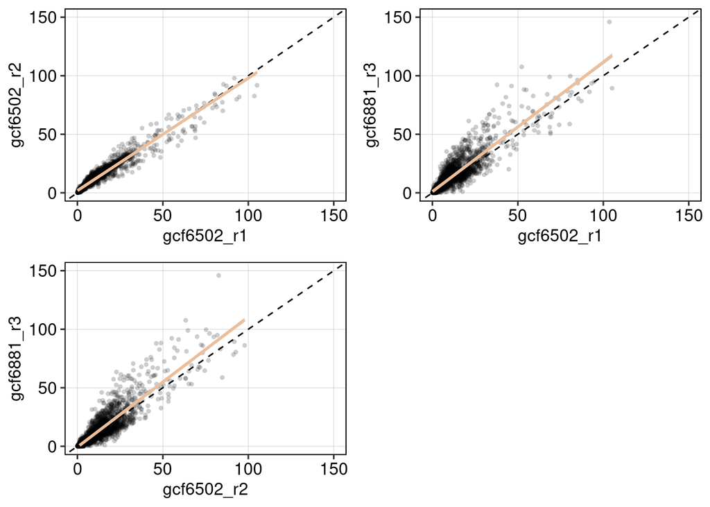

```
## [1] 0.975064
```

```
## [1] 0.9221576
```

```
## [1] 0.9230016
```

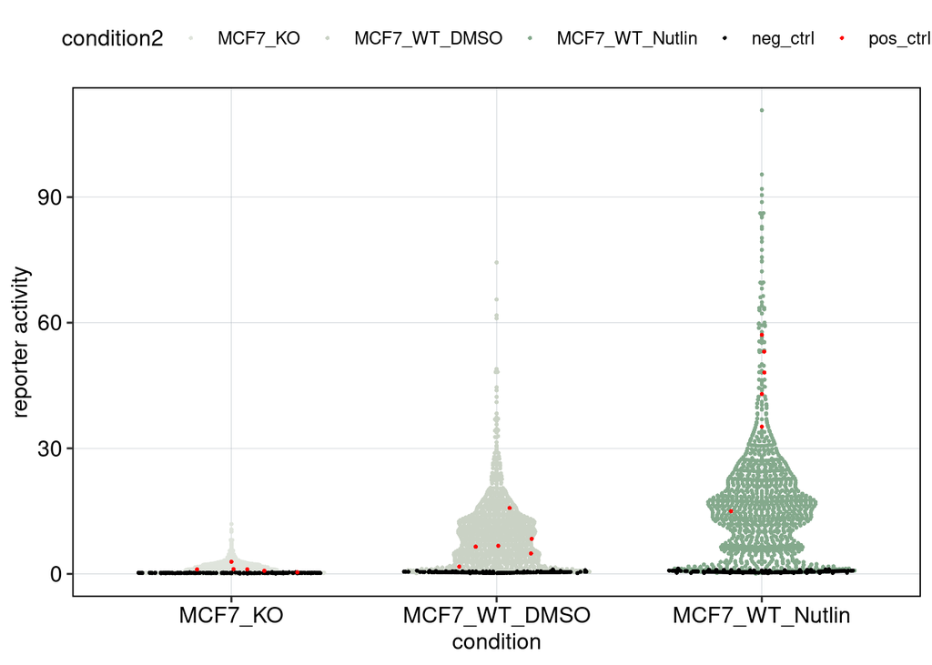

Conclusion: 1F: Replicates do correlate well. 1G: Negative controls are inactive compared to P53 reporters. P53 reporters become more active in WT cells and even more active upon Nutlin stimulation.

## Figure 2: Effect of affinity and binding sites + binding site positioning

Aim: How does the binding site affinity, copy number, and their respective positioning affect reporter activity?

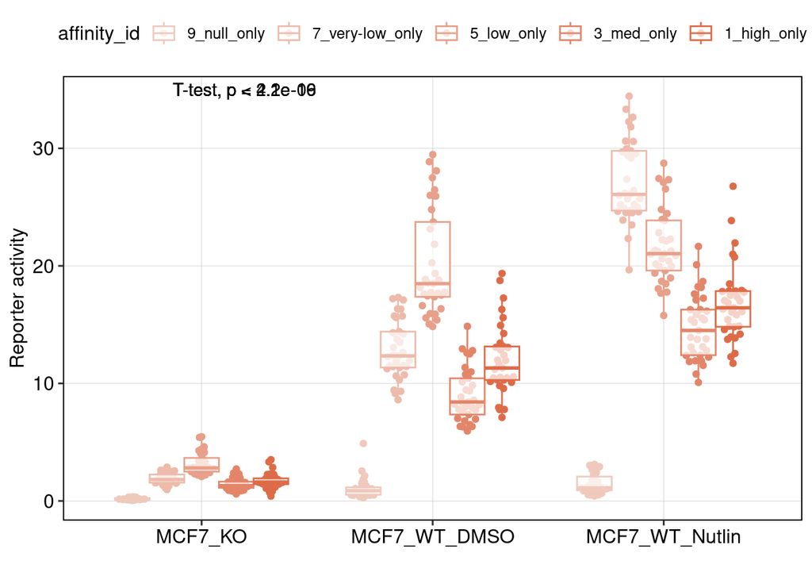

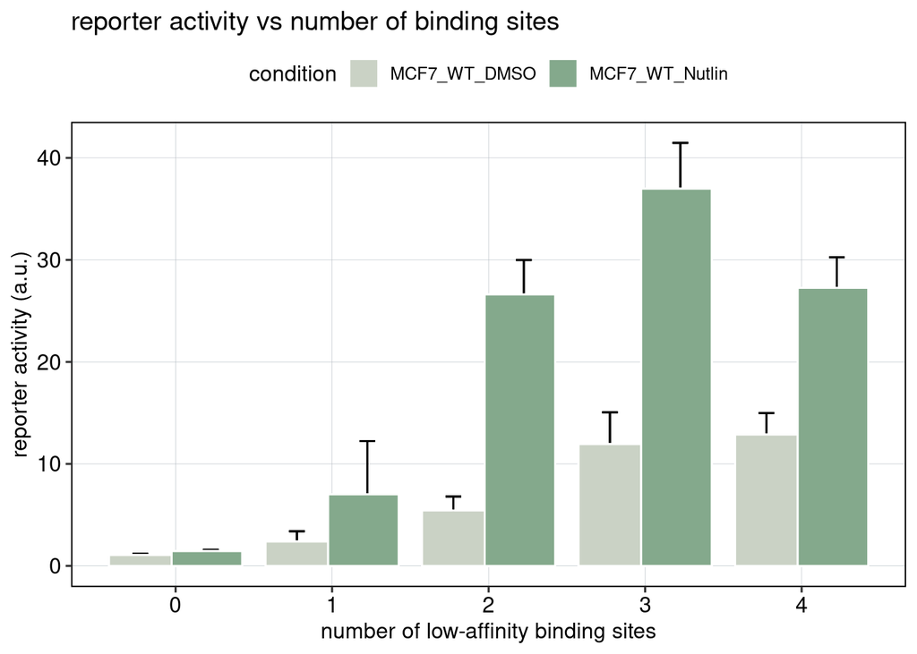

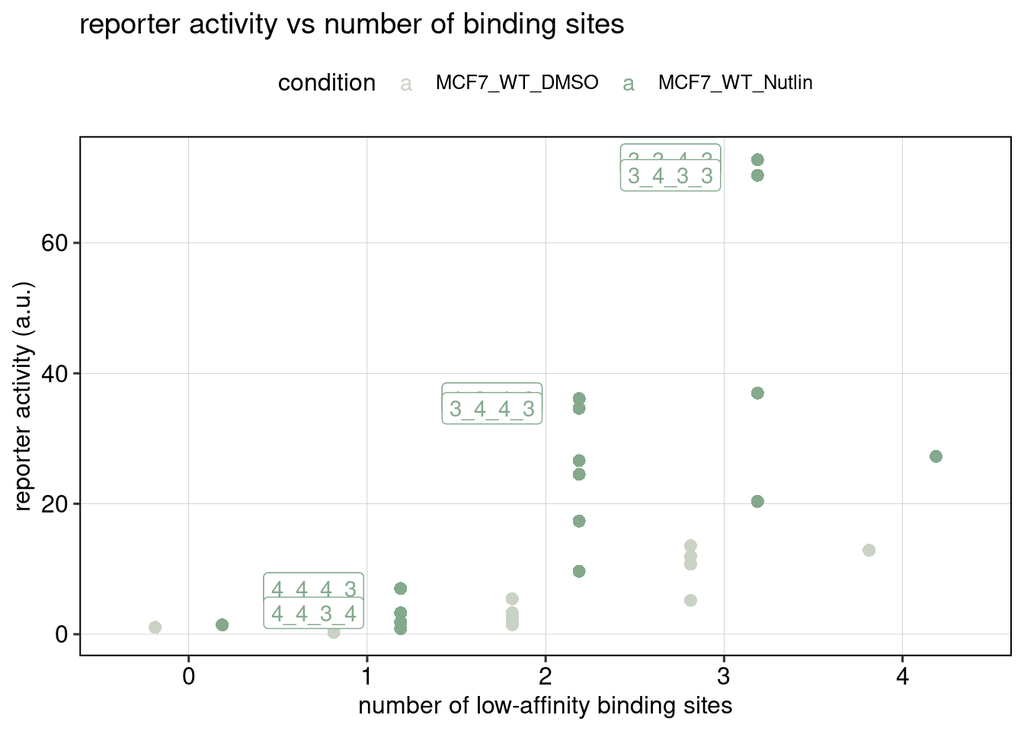

Conclusion: BS006 is the most responsive to Nutlin-3a. Addition of binding sites is super-additive. Positioning of binding sites matters - putting them directly next to each other is inhibitory, and putting them close to the TSS leads to higher activity.

Figure 3: The effect of the spacer length.

Aim: Show how the spacer length between adjacent binding sites affects reporter activity.

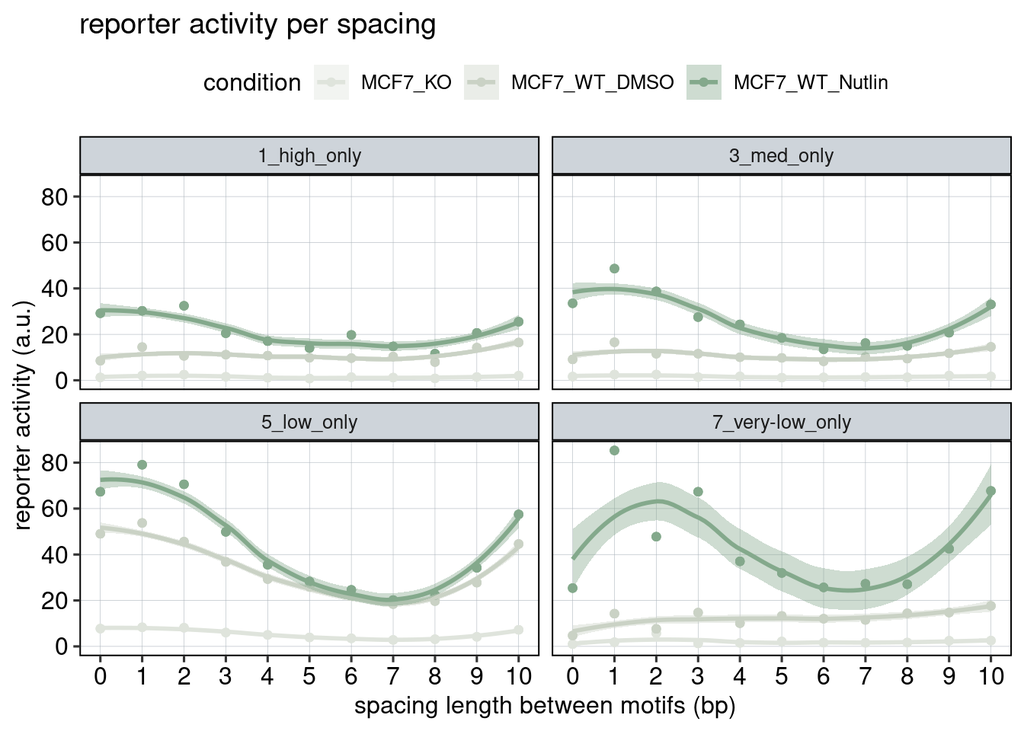

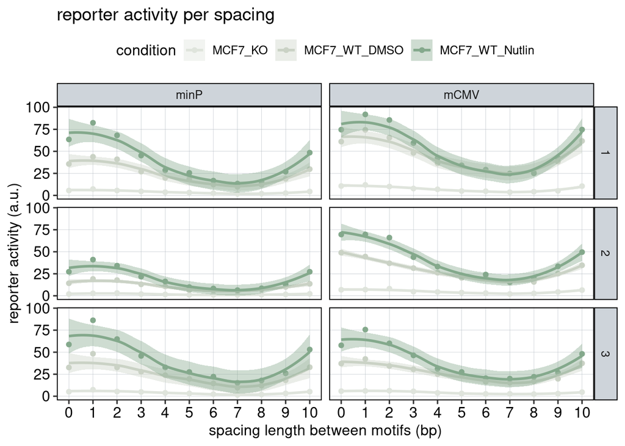

## Figure 4: The effect of the minimal promoter and the spacer sequence.

Aim: Show how the P53 reporters interact with the two minimal promoters and the three spacer sequences.

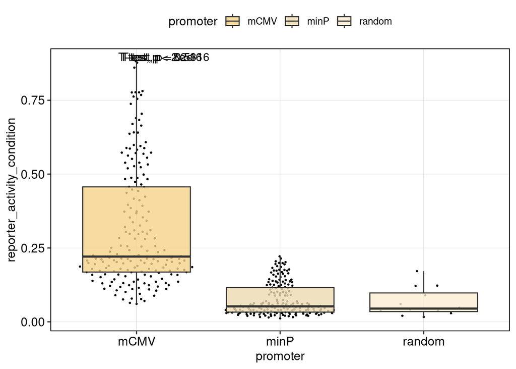

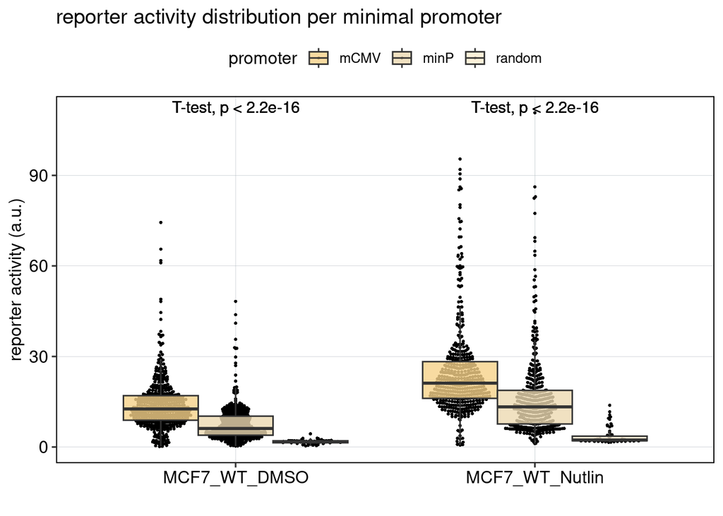

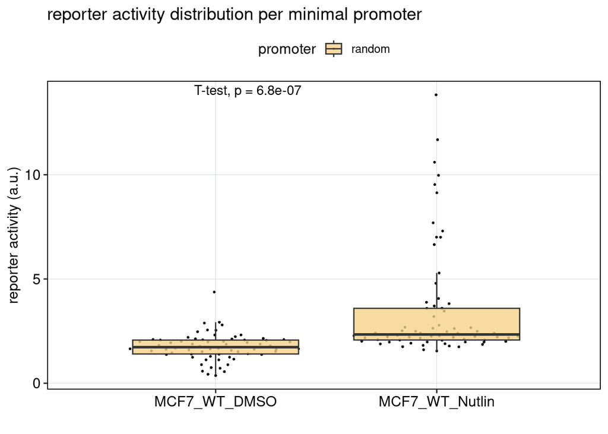

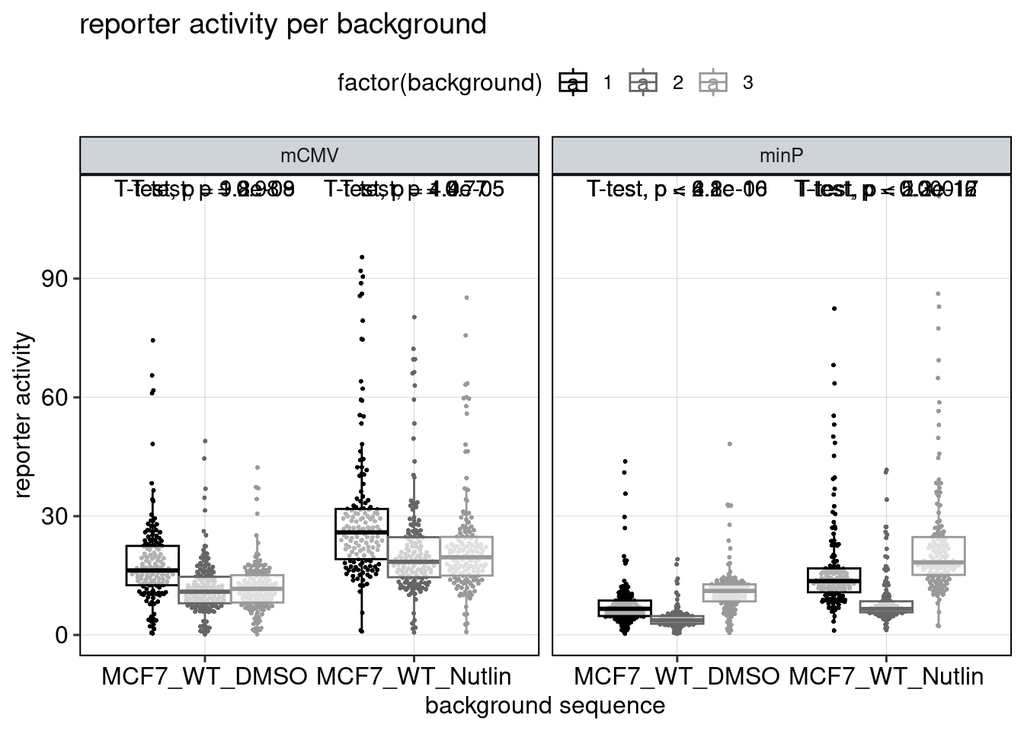

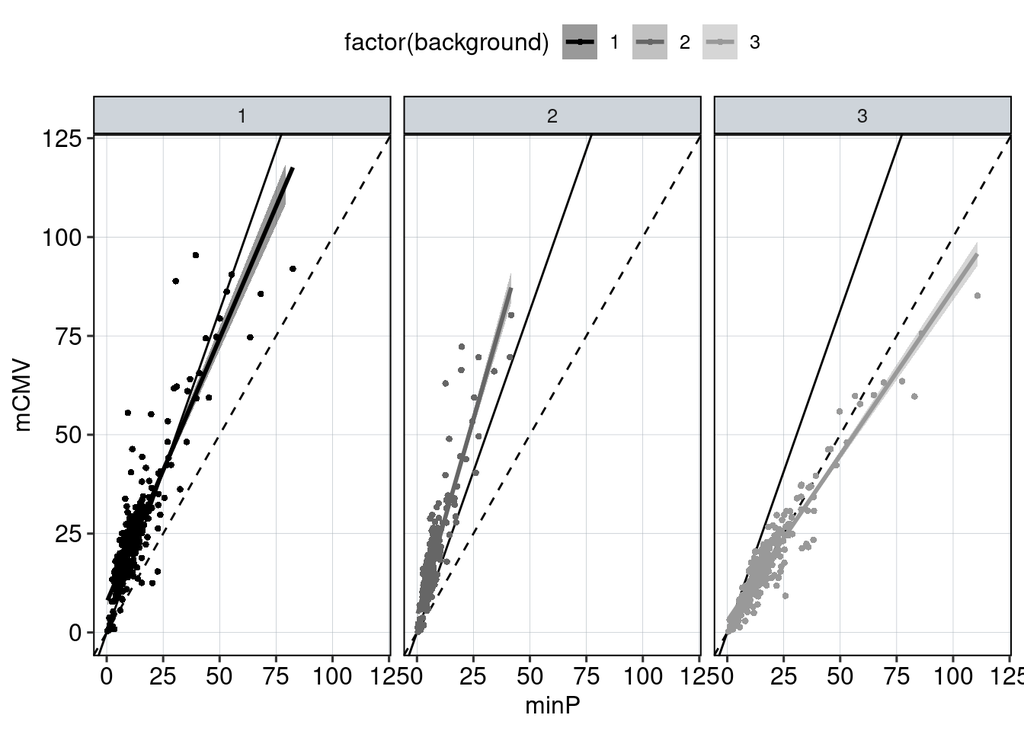

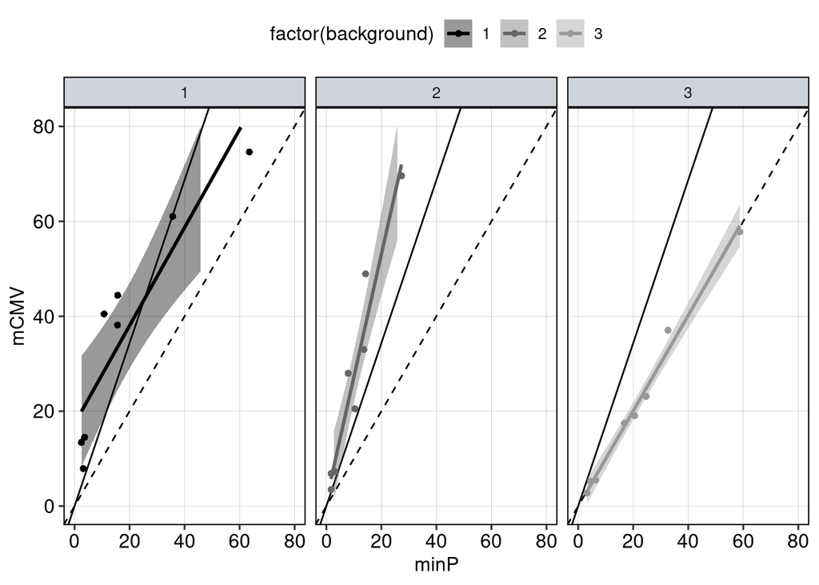

## Figure 5 & 6: Linear model + Selection of best reporters

Aim: Can we explain now every observation using a linear model?

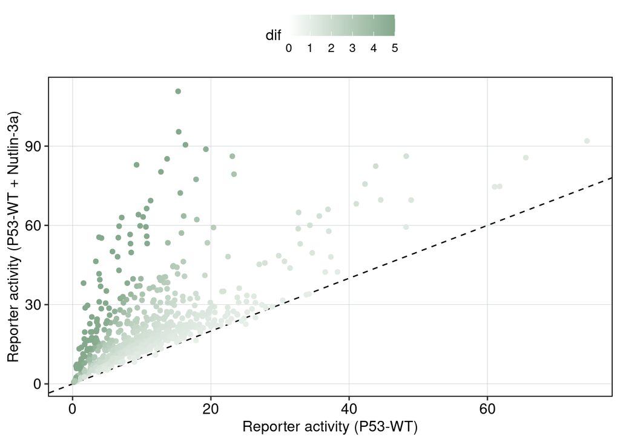

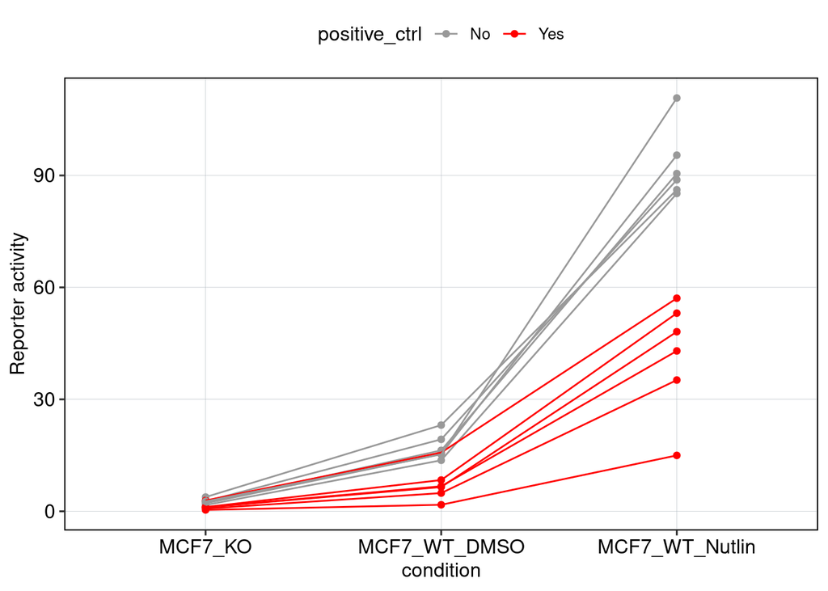

```
## MODEL INFO:
## Observations: 264
## Dependent Variable: log2(reporter_activity)
## Type: OLS linear regression
##
## MODEL FIT:
## F(9,254) = 109.78, p = 0.00
## R² = 0.80
## Adj. R² = 0.79
##
## Standard errors: OLS
## ---------------------------------------------------------------
##                                     Est.   S.E.   t val.      p
## -------------------------------- ------- ------ -------- ------
## (Intercept)                         3.98   0.08    49.82   0.00
## spacing_degree_transf               0.76   0.04    20.14   0.00
## promotermCMV                        0.66   0.09     7.14   0.00
## background2                        -0.93   0.09   -10.10   0.00
## background3                         0.33   0.09     3.54   0.00
## affinity_id3_med_only               0.21   0.08     2.82   0.01
## affinity_id5_low_only               0.94   0.08    12.54   0.00
## affinity_id7_very-low_only          0.88   0.08    11.75   0.00
## promotermCMV:background2            0.46   0.13     3.55   0.00
## promotermCMV:background3           -0.75   0.13    -5.79   0.00
## ---------------------------------------------------------------
```

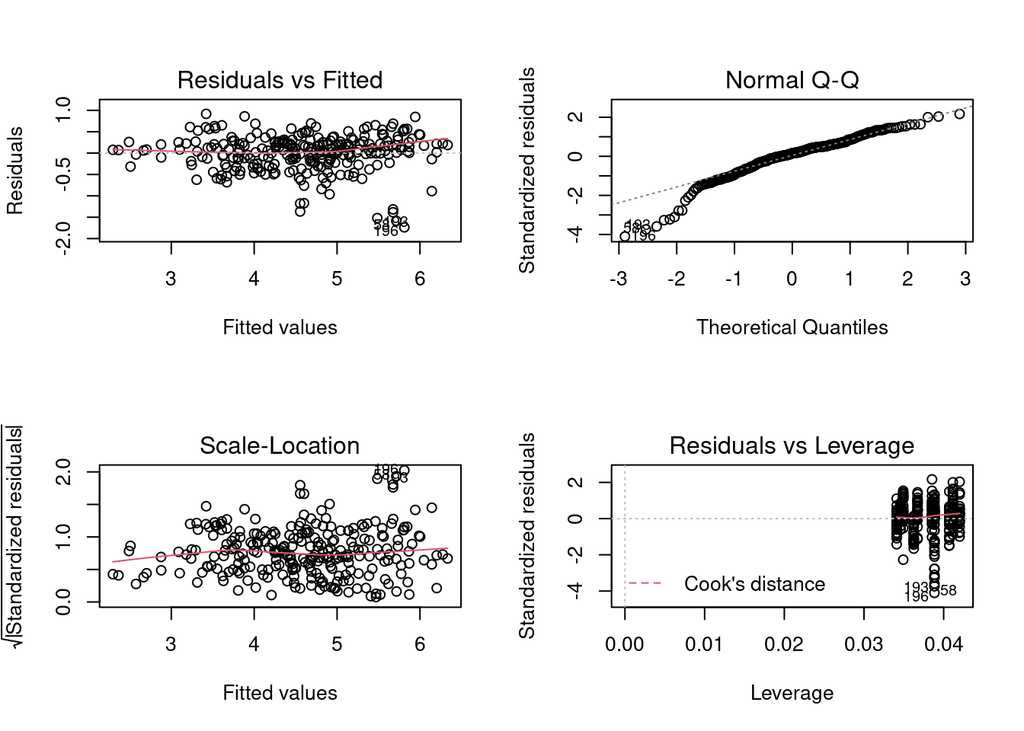

```
## MODEL INFO:
## Observations: 264
## Dependent Variable: log2(reporter_activity)
## Type: OLS linear regression
##
## MODEL FIT:
## F(9,254) = 92.40, p = 0.00
## R² = 0.77
## Adj. R² = 0.76
##
## Standard errors: OLS
## ---------------------------------------------------------------
##                                     Est.   S.E.   t val.      p
## -------------------------------- ------- ------ -------- ------
## (Intercept)                         2.77   0.10    28.65   0.00
## spacing_degree_transf               0.28   0.05     6.17   0.00
## promotermCMV                        1.13   0.11    10.08   0.00
## background2                        -0.92   0.11    -8.25   0.00
## background3                         0.50   0.11     4.44   0.00
## affinity_id3_med_only              -0.10   0.09    -1.08   0.28
## affinity_id5_low_only               1.46   0.09    16.04   0.00
## affinity_id7_very-low_only         -0.05   0.09    -0.58   0.56
## promotermCMV:background2            0.26   0.16     1.64   0.10
## promotermCMV:background3           -1.12   0.16    -7.10   0.00
## ---------------------------------------------------------------
```

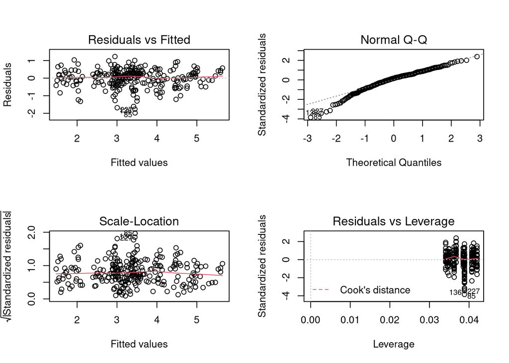

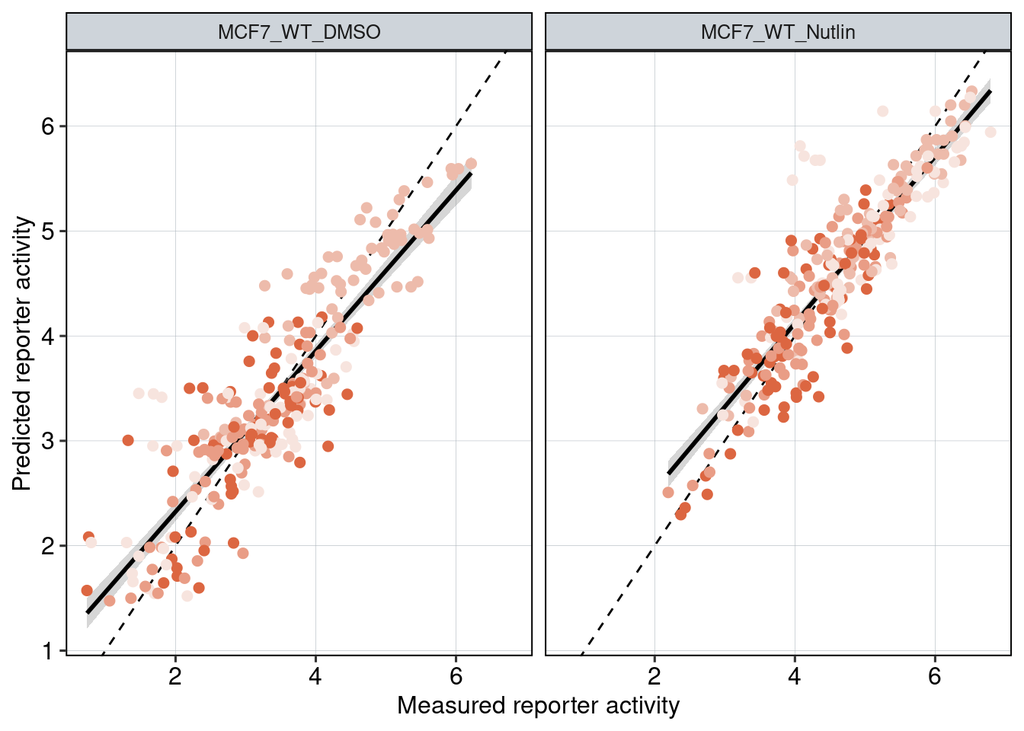

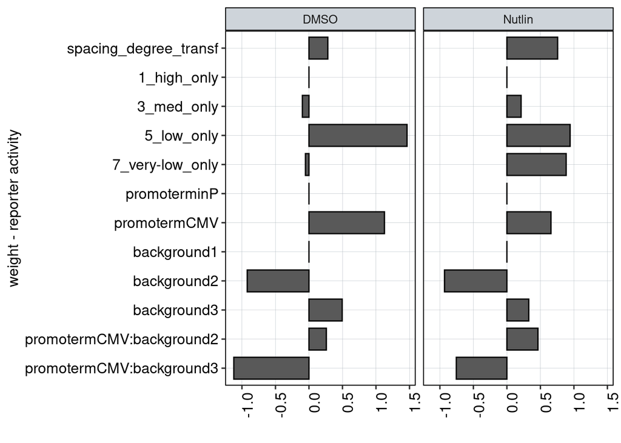

Conlusion: Top reporters are better than commercial reporters. Linear model gives insights into which features are important to drive high expression.

# Session Info

```r
paste("Run time: ",format(Sys.time()-StartTime))
```

```
## [1] "Run time:  22.40483 secs"
```

```r
getwd()
```

```
## [1] "/DATA/usr/m.trauernicht/projects/P53_reporter_scan/analyses"
```

```r
date()
```

```
## [1] "Tue Feb  7 16:37:41 2023"
```